# Script_de_amostragem

# Exercício de amostragem

Carregamento do dataset

```r
library(ggplot2)
d <- diamonds
```

Geração de amosrtras o espaço em branco após a virgula indica que todos os itens serão pegos

```r
a1 <- d[1:3000,]
```

Cálculo da média da var price da população e da amostra (para pegar uma variável dentro do dataframe utiliza-se $)

```r
mean(d$price)
```

```
## [1] 3932.8
```

```r
mean(a1$price)
```

```
## [1] 2739.121
```

Cálculo da mediana da var price da população e da amostra

```r
median(d$price)
```

```
## [1] 2401
```

```r
median(a1$price)
```

```
## [1] 2963
```

Cálculo do descio padrão da var price da população e da amostra

```r
sd(d$price)
```

```
## [1] 3989.44
```

```r
sd(a1$price)
```

```
## [1] 793.5682
```

Pegar nova amostra

```r
a2 <- d[3001:6000,]
mean(d$price)
```

```
## [1] 3932.8
```

```r
mean(a1$price)
```

```
## [1] 2739.121
```

```r
mean(a2$price)
```

```
## [1] 3324.448
```

```r
median(d$price)
```

```
## [1] 2401
```

```r
median(a1$price)
```

```
## [1] 2963
```

```r
median(a2$price)
```

```
## [1] 3601
```

```r
sd(d$price)
```

```
## [1] 3989.44
```

```r
sd(a1$price)
```

```
## [1] 793.5682
```

```r
sd(a2$price)
```

```
## [1] 940.9146
```

Geração de amostra aleatória

```r
sample(3)
```

```
## [1] 2 3 1
```

Definição da semente de elatoriedade (manter o mesmo conjunto de dados)

```r
set.seed(33)
sample(3)
```

```
## [1] 2 3 1
```

Geração de vetor de números aleatórios

```r
vn <- sample(53940)
```

Geração de amostra aleatória

```r
a3 <- d[vn[1:3000],]
```

Análise dos indicadores

```r
mean(a3$price)
```

```
## [1] 3902.865
```

```r
median(a3$price)
```

```
## [1] 2316.5
```

```r
sd(a3$price)
```

```
## [1] 4056.295
```

Histograma

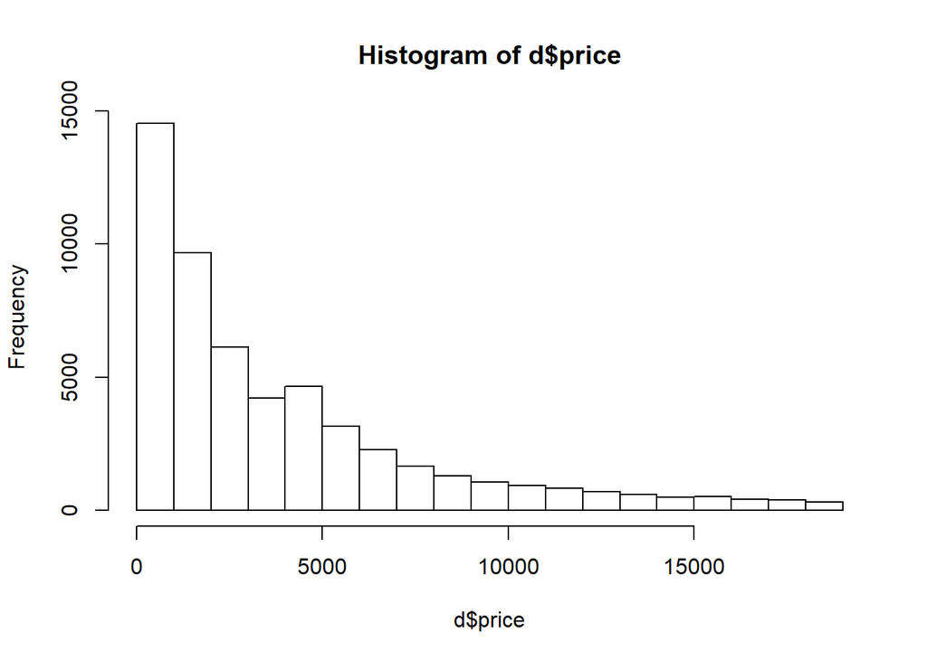

```r
hist(d$price)
```

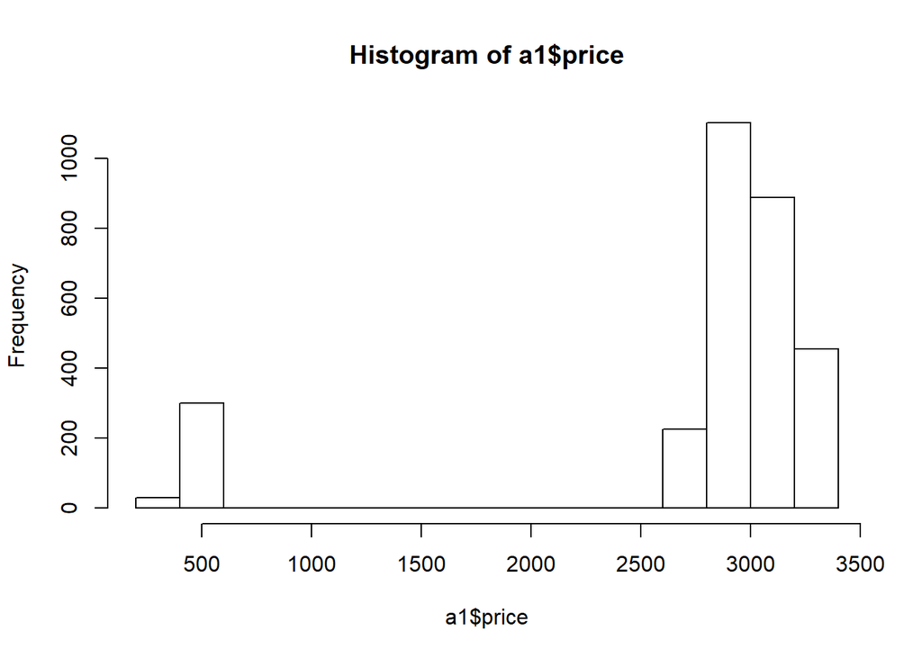

```r
hist(a1$price)
```

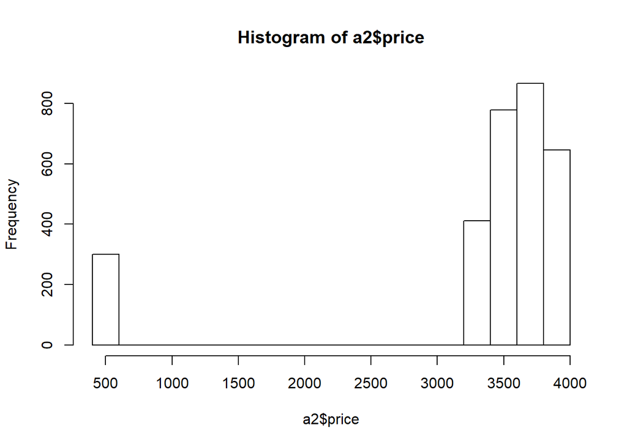

```r
hist(a2$price)
```

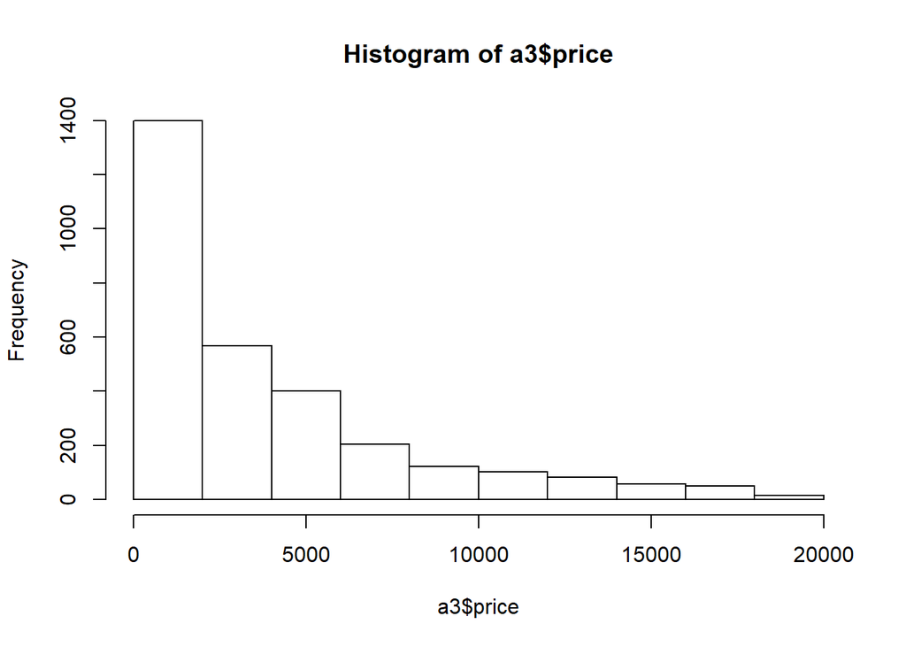

```r
hist(a3$price)
```

Boxplot simbolo ~ representa “em relação a” gráfico de preços em relação ao corte do diamante

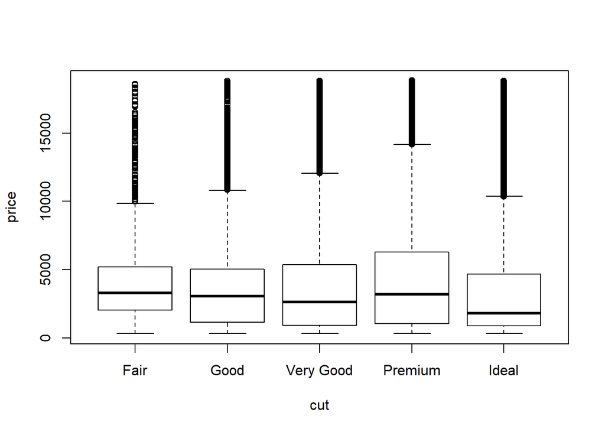

```r
boxplot(price~cut, data=d)
```

Comando summary apresenta os elementos principais do dataset

```r
summary(d$price)
```

```
##    Min. 1st Qu.  Median    Mean 3rd Qu.    Max.
##     326     950    2401    3933    5324   18823
```

```r
summary(a3$price)
```

```
##    Min. 1st Qu.  Median    Mean 3rd Qu.    Max.
##   351.0   938.8  2316.5  3902.9  5260.2 18768.0
```

comando para criar duas colunas no frame de visualização ideal para colocar gráficos lado a lado de datasets diferentes

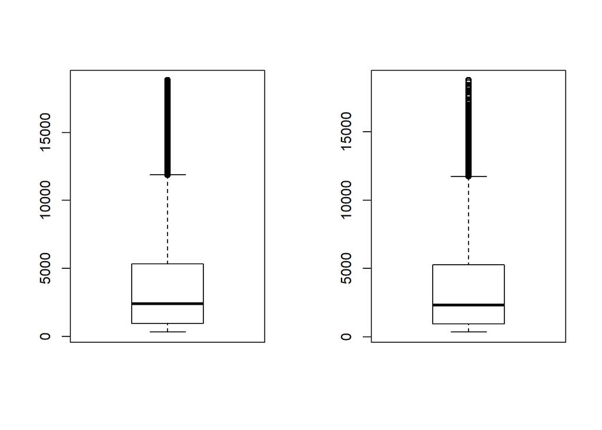

```r
par(mfrow=(c(1,2))) # para voltar ao normal par(mfrow=(c(1,1)))
boxplot(d$price)
boxplot(a3$price)
```

Gráfico de dispersão

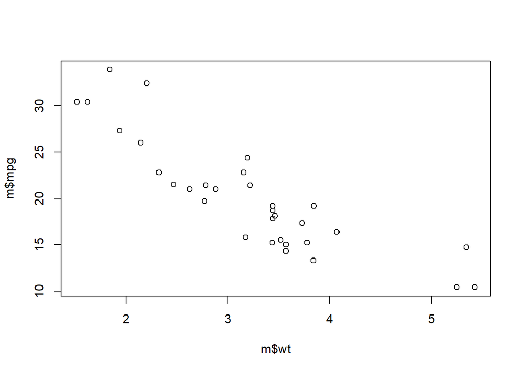

```r
m <- mtcars
plot(m$mpg~m$wt)
```

cálculo do coeficiente de correlação linear positivo = relação direta negativo = relação inversa quanto mais perto de 1 (e -1) mais se parece com uma reta

```r
cor(m$mpg, m$wt)
```

```
## [1] -0.8676594
```

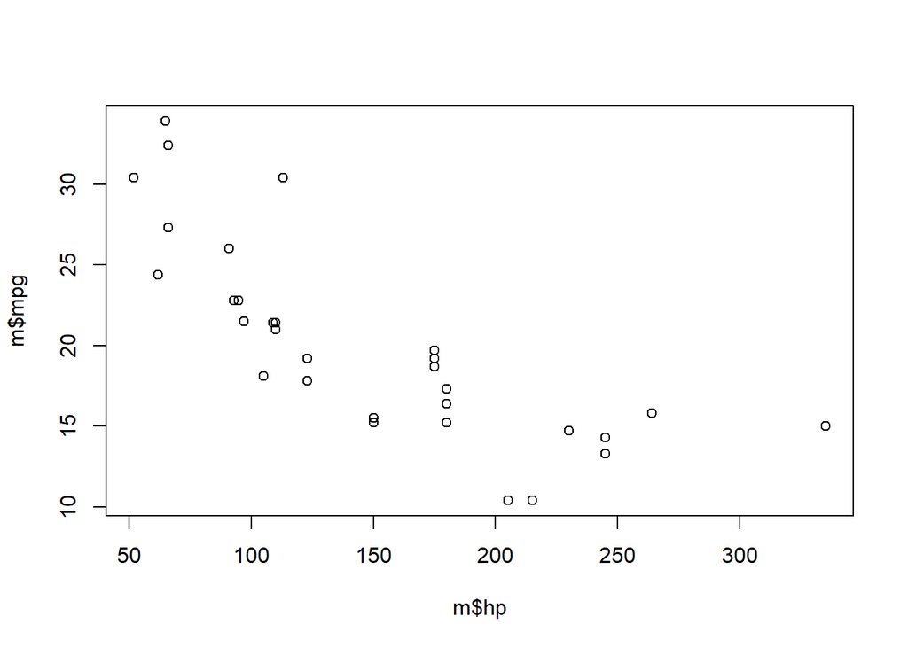

```r
plot(m$mpg~m$hp)
```

relação de todas as variáveis em relação a todas a variaveis

```r
cor(m)
```

```
##             mpg        cyl       disp         hp        drat         wt
## mpg   1.0000000 -0.8521620 -0.8475514 -0.7761684  0.68117191 -0.8676594
## cyl  -0.8521620  1.0000000  0.9020329  0.8324475 -0.69993811  0.7824958
## disp -0.8475514  0.9020329  1.0000000  0.7909486 -0.71021393  0.8879799
## hp   -0.7761684  0.8324475  0.7909486  1.0000000 -0.44875912  0.6587479
## drat  0.6811719 -0.6999381 -0.7102139 -0.4487591  1.00000000 -0.7124406
## wt   -0.8676594  0.7824958  0.8879799  0.6587479 -0.71244065  1.0000000
## qsec  0.4186840 -0.5912421 -0.4336979 -0.7082234  0.09120476 -0.1747159
## vs    0.6640389 -0.8108118 -0.7104159 -0.7230967  0.44027846 -0.5549157
## am    0.5998324 -0.5226070 -0.5912270 -0.2432043  0.71271113 -0.6924953
## gear  0.4802848 -0.4926866 -0.5555692 -0.1257043  0.69961013 -0.5832870
## carb -0.5509251  0.5269883  0.3949769  0.7498125 -0.09078980  0.4276059
##             qsec         vs          am       gear        carb
## mpg   0.41868403  0.6640389  0.59983243  0.4802848 -0.55092507
## cyl  -0.59124207 -0.8108118 -0.52260705 -0.4926866  0.52698829
## disp -0.43369788 -0.7104159 -0.59122704 -0.5555692  0.39497686
## hp   -0.70822339 -0.7230967 -0.24320426 -0.1257043  0.74981247
## drat  0.09120476  0.4402785  0.71271113  0.6996101 -0.09078980
## wt   -0.17471588 -0.5549157 -0.69249526 -0.5832870  0.42760594
## qsec  1.00000000  0.7445354 -0.22986086 -0.2126822 -0.65624923
## vs    0.74453544  1.0000000  0.16834512  0.2060233 -0.56960714
## am   -0.22986086  0.1683451  1.00000000  0.7940588  0.05753435
## gear -0.21268223  0.2060233  0.79405876  1.0000000  0.27407284
## carb -0.65624923 -0.5696071  0.05753435  0.2740728  1.00000000
```